# Tutorial 6: La forma de una distribución

Estadística I — Matemáticas Aplicadas y Computación

Dra. Elizabeth Martínez Gómez

# Propósito

Hasta ahora hemos estudiado centro y dispersión. Pero dos distribuciones pueden tener valores de centro y dispersión similares y, aun así, presentar formas muy diferentes.

Usaremos:

- vida a fatiga del aluminio;
- un conjunto NIST diseñado para mostrar el efecto de valores atípicos.

El conjunto de fatiga contiene 101 mediciones de vida hasta ruptura bajo carga periódica. [NIST, BIRNSAUN.DAT](https://www.itl.nist.gov/div898/handbook/datasets/BIRNSAUN.DAT).

El conjunto `COMPARE-7_1_6.DAT` contiene 90 observaciones y fue incluido por NIST para ilustrar el análisis de valores atípicos. [NIST, COMPARE-7_1_6.DAT](https://www.itl.nist.gov/div898/handbook/datasets/COMPARE-7_1_6.DAT).

```r
knitr::opts_chunk$set(echo = TRUE, message = FALSE, warning = FALSE)

library(ggplot2)

setwd("/home/nani/Documents/Universidad/2027-I/Estadistica/Actividades/Tutoriales estadística")
fatiga <- read.csv("Datos/Dana Amador - BIRNSAUN.csv")
attach(fatiga)
names(fatiga)
```

```
## [1] "vida"
```

```r
out <- read.csv("Datos/Dana Amador - COMPARE-7_1_6.csv")
attach(out)
names(out)
```

```
## [1] "y"
```

# 1. La forma no se reduce a “parece una campana”

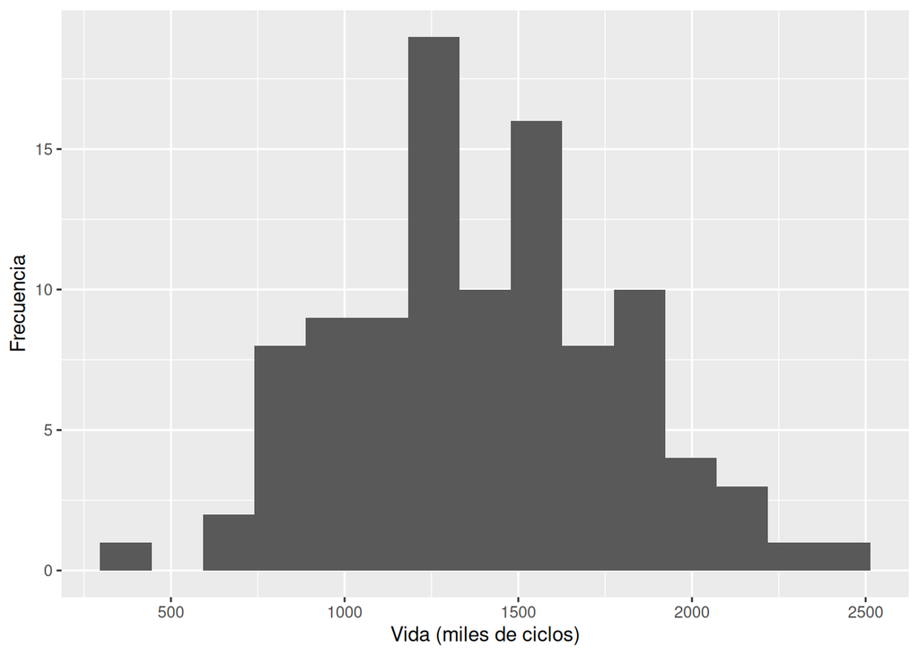

```r
ggplot(fatiga, aes(x = vida)) +
  geom_histogram(bins = 15) +
  labs(x = "Vida (miles de ciclos)", y = "Frecuencia")
```

Describe:

- simetría/asimetría;
- cola derecha o izquierda;
- concentración;
- posibles valores extremos;
- unimodalidad o multimodalidad.

# 2. Media y mediana como pistas de asimetría

```r
c(
  media = mean(fatiga$vida),
  mediana = median(fatiga$vida)
)
```

```
##    media  mediana
## 1400.911 1416.000
```

Una diferencia apreciable entre media y mediana puede ser consistente con asimetría.

**Pero no es una prueba suficiente de la forma.**

Siempre debemos mirar la distribución.

# 3. Asimetría basada en momentos

Podemos construir un coeficiente descriptivo basado en el tercer momento central:

$$m_k=\frac{1}{n}\sum_{i=1}^n(x_i-\bar{x})^k.$$

Una versión sencilla del coeficiente de asimetría es:

$$g_1=\frac{m_3}{m_2^{3/2}}.$$

```r
skewness_moment <- function(x) {
  m <- mean(x)
  m2 <- mean((x - m)^2)
  m3 <- mean((x - m)^3)
  m3 / m2^(3/2)
}

skewness_moment(fatiga$vida)
```

```
## [1] 0.1400091
```

### Precaución

Esta es una medida descriptiva basada en momentos. Existen diferentes convenciones y correcciones de sesgo para estimar asimetría muestral.

En este curso importa entender **qué momento se está utilizando y qué información geométrica aporta**, no memorizar una única fórmula universal.

# 4. Curtosis

El cuarto momento central es:

$$m_4=\frac{1}{n}\sum_{i=1}^n(x_i-\bar{x})^4.$$

La curtosis basada en momentos puede escribirse:

$$\beta_2=\frac{m_4}{m_2^2}.$$

La **exceso de curtosis** es:

$$g_2=\beta_2-3.$$

```r
kurtosis_excess <- function(x) {
  m <- mean(x)
  m2 <- mean((x - m)^2)
  m4 <- mean((x - m)^4)
  m4 / m2^2 - 3
}

kurtosis_excess(fatiga$vida)
```

```
## [1] -0.2338613
```

## Actividad 1

Explica por qué elevar a la cuarta potencia hace que las observaciones alejadas de la media tengan una influencia muy grande.

# 5. Valores extremos

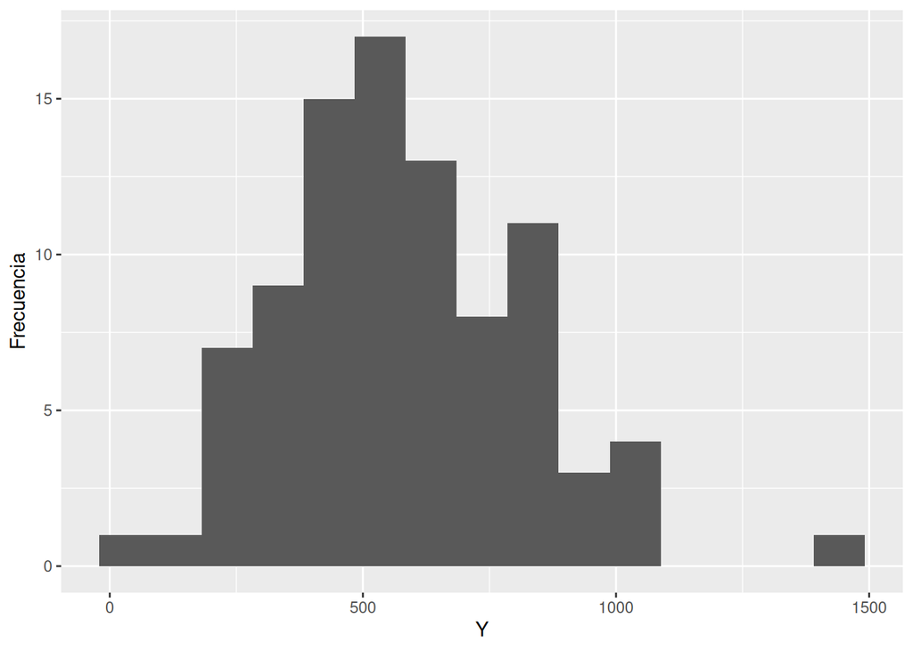

```r
ggplot(out, aes(x = y)) +
  geom_histogram(bins = 15) +
  labs(x = "Y", y = "Frecuencia")
```

Observa especialmente el extremo superior.

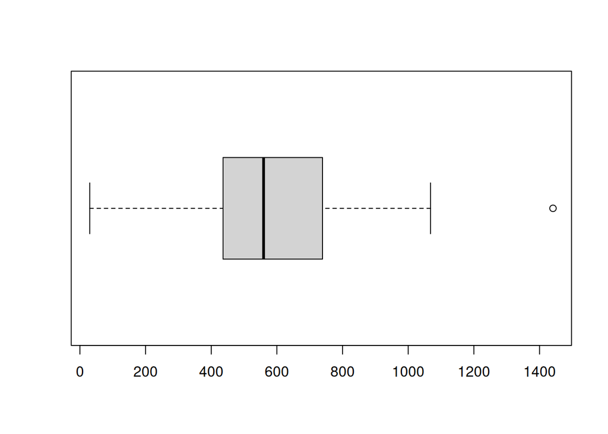

```r
boxplot(out$y, horizontal = TRUE)
```

El NIST identifica este conjunto específicamente como ejemplo de análisis de valores atípicos. [NIST](https://www.itl.nist.gov/div898/handbook/datasets/COMPARE-7_1_6.DAT).

# 6. Actividad 2 — ¿Qué estadística cambia más?

Calcula:

```r
c(
  media = mean(out$y),
  mediana = median(out$y),
  sd = sd(out$y),
  IQR = IQR(out$y),
  asimetria = skewness_moment(out$y),
  exceso_curtosis = kurtosis_excess(out$y)
)
```

```
##           media         mediana              sd             IQR       asimetria
##     576.0777778     559.5000000     237.6000902     302.2500000       0.5424705
## exceso_curtosis
##       0.8244290
```

Ahora elimina temporalmente la observación máxima:

```r
out_sin_max <- out$y[-which.max(out$y)]

c(
  media = mean(out_sin_max),
  mediana = median(out_sin_max),
  sd = sd(out_sin_max),
  IQR = IQR(out_sin_max),
  asimetria = skewness_moment(out_sin_max),
  exceso_curtosis = kurtosis_excess(out_sin_max)
)
```

```
##           media         mediana              sd             IQR       asimetria
##     566.3595506     559.0000000     220.2243818     301.0000000       0.1299611
## exceso_curtosis
##      -0.4817332
```

### Pregunta

¿Qué medidas son particularmente sensibles al valor extremo?

Explica por qué desde las fórmulas.

# 7. Unimodalidad y multimodalidad

Una distribución puede presentar más de una concentración de observaciones.

No siempre una sola media representa bien una distribución multimodal.

## Actividad 3

Busca visualmente si alguno de los conjuntos anteriores presenta indicios de más de una concentración.

No afirmes “hay dos poblaciones” sólo porque aparecen dos picos.

Explica qué información adicional necesitarías para sostener esa interpretación.

# 8. Síntesis de forma

Para describir una distribución utiliza este orden:

1. localización;
2. dispersión;
3. forma;
4. extremos.

## Actividad 4

Escribe una descripción estadística completa de `fatiga$vida` en 8–12 líneas.

No utilices sólo adjetivos como “grande”, “pequeña” o “normal”.

Incluye medidas y evidencia gráfica.

# Autoevaluación

**Debes poder explicar**

- qué es un momento central;
- por qué el tercer momento está relacionado con asimetría;
- por qué el cuarto momento es sensible a extremos;
- diferencia entre curtosis y exceso de curtosis;
- por qué media y mediana pueden ayudar a detectar asimetría;
- por qué ninguna medida aislada describe completamente una distribución.

## Reto matemático

Demuestra que para cualquier constante $c$,

$$\frac{1}{n}\sum_{i=1}^n(x_i-c)^2$$

se minimiza cuando $c=\bar{x}$.

Relaciona este resultado con la interpretación de la media como centro de mínimos cuadrados.